# CRIC and SMART2D participants with 7 year follow up (Table 5)

Rabiul Islam Center for Renal Precision Medicine University of Texas Health San Antonio School of Medicine

2022-03-31

Center for Renal Precision Medicine

# 1 Brief

```r
#Requirements
requirements <- c("adapr","survival","survminer","dplyr","CBPS","purrr","gtsummary","gt","cobalt","officer","rvg","lme4","lmerTest","effects","emmeans","readxl","tableone")

#CRAN repository
repos <- "http://cran.us.r-project.org"

#install and load missing requirements
for (pack in requirements){
  if( !is.element(pack, .packages(all.available = TRUE)) ) {
    #install.packages(pack, repos = repos)
    install.packages(pack)
  }
  library(pack, character.only = TRUE)
}
```

```r
#Constants
rm(list=ls())
set.seed( 2011 )
MWade = 135.13 # molecular weights for adenine in g/mol
MWcre = 113.12 #molecular weights for creatinine in g/mol
```

# 2 Smart2d dataset analysis

## 2.1 Load SMART2D dataset here preprocessing

```r
#get data
#smartdata <- read_excel("SMART2D.xlsx")
smartdata <- read_excel("SMART.xlsx")
```

## 2.2 Apply cox’s model to Full cohorts with Unadjusted

```r
#Select eGFR from 20 to 60
#smartdata<-smartdata[which(smartdata$ckd_epi >=20 & smartdata$ckd_epi<=60),]
#Apply cox's model to Normal+Micro
coxobj_Q2vsQ1<-coxph(formula=Surv(smartdata$time_to_composite__renal_revised, smartdata$composite_renal_sep2019)~
                        SD_Ln_AdCre, data = smartdata)
print(paste("Cox's model Results for Normal+Micro= "))
```

```
## [1] "Cox's model Results for Normal+Micro= "
```

```r
coxobj_Q2vsQ1
```

```
## Call:
## coxph(formula = Surv(smartdata$time_to_composite__renal_revised,
##     smartdata$composite_renal_sep2019) ~ SD_Ln_AdCre, data = smartdata)
##
##               coef exp(coef) se(coef)    z        p
## SD_Ln_AdCre 0.5800    1.7860   0.1701 3.41 0.000649
##
## Likelihood ratio test=11.49  on 1 df, p=0.0007012
## n= 309, number of events= 40
```

```r
exp(confint(coxobj_Q2vsQ1))
```

```
##                2.5 %   97.5 %
## SD_Ln_AdCre 1.279717 2.492498
```

## 2.3 Apply cox’s model to Full cohorts with adjusted

```r
#Apply cox's model to Normal+Micro
coxobj_Q2vsQ1<-coxph(formula=Surv(smartdata$time_to_composite__renal_revised, smartdata$composite_renal_sep2019)~
                        SD_Ln_AdCre+age+sex+duration_of_diabetes+mean_BP+HbA1c+ckd_epi+LnACR, data = smartdata)

print(paste("Cox's model Results for Normal+Micro= "))
```

```
## [1] "Cox's model Results for Normal+Micro= "
```

```r
coxobj_Q2vsQ1
```

```
## Call:
## coxph(formula = Surv(smartdata$time_to_composite__renal_revised,
##     smartdata$composite_renal_sep2019) ~ SD_Ln_AdCre + age +
##     sex + duration_of_diabetes + mean_BP + HbA1c + ckd_epi +
##     LnACR, data = smartdata)
##
##                           coef exp(coef)  se(coef)      z       p
## SD_Ln_AdCre           0.441464  1.554982  0.181689  2.430 0.01511
## age                   0.006504  1.006526  0.018049  0.360 0.71856
## sex                  -0.718780  0.487347  0.376911 -1.907 0.05652
## duration_of_diabetes -0.013449  0.986641  0.018475 -0.728 0.46665
## mean_BP               0.001524  1.001525  0.016118  0.095 0.92466
## HbA1c                 0.212365  1.236600  0.128207  1.656 0.09764
## ckd_epi              -0.038978  0.961772  0.013652 -2.855 0.00430
## LnACR                 0.510321  1.665826  0.156632  3.258 0.00112
##
## Likelihood ratio test=50.93  on 8 df, p=2.709e-08
## n= 306, number of events= 39
##    (3 observations deleted due to missingness)
```

```r
exp(confint(coxobj_Q2vsQ1))
```

```
##                          2.5 %   97.5 %
## SD_Ln_AdCre          1.0891091 2.220134
## age                  0.9715420 1.042769
## sex                  0.2328148 1.020153
## duration_of_diabetes 0.9515535 1.023023
## mean_BP              0.9703802 1.033670
## HbA1c                0.9618320 1.589860
## ckd_epi              0.9363781 0.987855
## LnACR                1.2254739 2.264412
```

# 3 Defined ACR group based on ACR categorical variable. Defined adenine teritle based on adenine_tertile_CRIC categorical variable. Commulative incidence plot for SMART dataset

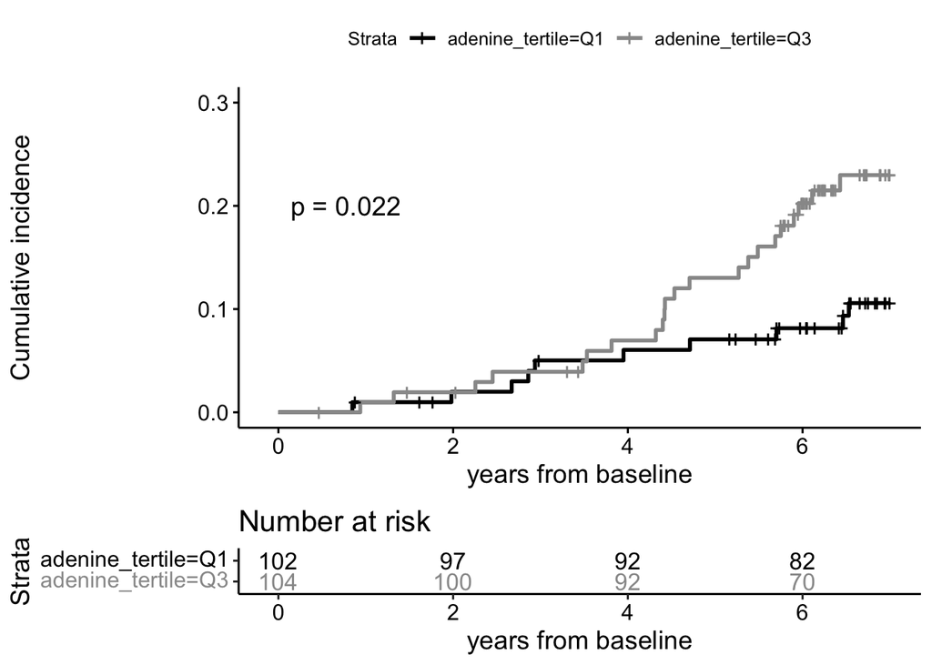

```r
subset_dataset1 = smartdata %>%
  mutate(acr_group = ifelse(is.na(ACR_category), NA, 'unknown'),
         acr_group = ifelse(ACR_category == 1, 'normo', acr_group),
         acr_group = ifelse(ACR_category == 2, 'micro', acr_group),
         acr_group = as.factor(acr_group),
         adenine_tertile = ifelse(is.na(adenine_tertile_CRIC), NA, 'unknown'),
         adenine_tertile = ifelse(adenine_tertile_CRIC == 1, 'Q1', adenine_tertile),
         adenine_tertile = ifelse(adenine_tertile_CRIC == 2, 'Q2', adenine_tertile),
         adenine_tertile = ifelse(adenine_tertile_CRIC == 3, 'Q3', adenine_tertile),
         sex2 = ifelse(sex == 1, 'Male', 'Female'),
         acr_sex_group = paste(acr_group, sex2, sep = '_'))


#Cumulative incidence plot for normo+Micro group


############################################################################################

#p-value estimate for Q1 and Q3 for Normo+Micro group
r3_p<-subset_dataset1%>%
  filter(adenine_tertile=='Q1' | adenine_tertile=='Q3')

inx<-which(r3_p$time_to_composite__renal_revised>=7)
r3_p[paste("time")]<-replace(r3_p$time_to_composite__renal_revised,inx,7)
r3_p[paste("event")]<-replace(r3_p$composite_renal_sep2019,inx,0)



ggsurvplot(survfit(Surv(r3_p$time, r3_p$event)~r3_p$adenine_tertile,data=r3_p),pval = TRUE, xlim=c(-0.1,7), ylim=c(0,0.3), conf.int = FALSE,
           palette = c("black", "grey60"),
           risk.table = TRUE, risk.table.col = "strata",
           fun = "event", xlab = "years from baseline",ylab = c("Cumulative incidence"))
```

```r
#surv_diff <- survdiff(Surv(r3_p$time, r3_p$event) ~ r3_p$adenine_tertile, data=r3_p)
#surv_diff
```

# 4 CRIC dataset analysis

## 4.1 Load redcap data in here and estimate 7 yrs follow up

```r
rawdata <- read.csv("RedCapUp2.csv")

t2 <- rawdata$sa_allc_cric_renal3_v3y0
inx<-which(rawdata$sa_allc_cric_time_renal3_v3y0>=7)
rawdata[paste("time")]<-replace(rawdata$sa_allc_cric_time_renal3_v3y0,inx,7)
rawdata[paste("event")]<-replace(rawdata$sa_allc_cric_renal3_v3y0,inx,0)
```

## 4.2 create new dataset (dataoutcome) with patientid, event, time, egfr_cric, and renal3

```r
dataoutcome<-cbind(rawdata["patientid"],rawdata["event"],rawdata["time"], rawdata["egfr_cric_v3y0"],rawdata["sa_allc_cric_renal3_v3y0"],rawdata["sa_allc_cric_time_renal3_v3y0"])
```

## 4.3 Load Roman dataset here

```r
#get data
load('/Users/rabiul/Documents/Projects/Sharma_653/Programs/surv_model_data.Rdata')
cric_data<-obj
```

## 4.4 Merge Roman dataset and dataoutcome. Defined ACR group and adenine teritle.

```r
cric_data<-merge(cric_data,dataoutcome,by="patientid")

cric_study_var<-c("patientid","event","time","race_ethnicity_cat","sex","age","bmi","hemoglobin_a1c","metformin","egfr_cric_v3y0","log_acr","albumin_creatinine_ratio","adenine","sa_allc_cric_renal3_v3y0","sa_allc_cric_time_renal3_v3y0","smoke100","map")
study_cricdata<-cric_data[cric_study_var]

# Cric tertile
map_to_tertile = function(x){

  quartiles = quantile(x, na.rm = T, probs = seq(0, 1, by = 1/3))

  vect_return = rep(NA, length(x)) %>%
    (function(vect) ifelse(x >= quartiles[1] & x < quartiles[2], 'Q1', vect)) %>%
    (function(vect) ifelse(x >= quartiles[2] & x < quartiles[3], 'Q2', vect)) %>%
    (function(vect) ifelse(x >= quartiles[3], 'Q3', vect)) %>%
    as.factor()

  return(vect_return)
}

subset_dataset = study_cricdata %>%
  mutate(log_adenine2 = log(adenine+1, base = 2),
         race_ethnicity_cat = as.character(race_ethnicity_cat),
         african_american = ifelse(race_ethnicity_cat == 'black', 'african-american', 'other'),
         hispanic = ifelse(race_ethnicity_cat == 'hispanic', 'hispanic', 'non-hispanic'),
         acr_group = ifelse(is.na(albumin_creatinine_ratio), NA, 'unknown'),
         acr_group = ifelse(albumin_creatinine_ratio <= 30, 'normo', acr_group),
         acr_group = ifelse(albumin_creatinine_ratio > 30 & albumin_creatinine_ratio <= 300, 'micro', acr_group),
         acr_group = ifelse(albumin_creatinine_ratio > 300, 'macro', acr_group),
         acr_group = as.factor(acr_group),
         adenine_cat = ifelse(log_adenine2 < median(log_adenine2, na.rm = T), 'Lower', 'Higher'),
         adenine_tertile = map_to_tertile(log_adenine2),
         sex2 = ifelse(sex == 1, 'Male', 'Female'),
         acr_sex_group = paste(acr_group, sex2, sep = '_'))
```

# 5 Estimate Baseline characteristics after merging the clinical variable and dataoutcome

```r
#Define covariates
covariates<-c("age", "sex2", "race_ethnicity_cat", "smoke100", "bmi", "map", "egfr_cric_v3y0","hemoglobin_a1c", "acr_group", "albumin_creatinine_ratio")

## Vector of categorical variables that need transformation
catVars <- c("sex2","race_ethnicity_cat","smoke100", "acr_group")


## Create a TableOne object
tab2 <- CreateTableOne(vars = covariates, data = subset_dataset, factorVars = catVars)

print(tab2)
```

```
##
##                                        Overall
##   n                                       905
##   age (mean (SD))                       60.00 (9.43)
##   sex2 = Male (%)                         515 (56.9)
##   race_ethnicity_cat (%)
##      black                                376 (41.5)
##      hispanic                             142 (15.7)
##      other                                 37 ( 4.1)
##      white                                350 (38.7)
##   smoke100 = 1 (%)                        510 (56.4)
##   bmi (mean (SD))                       33.98 (7.82)
##   map (mean (SD))                       90.08 (13.37)
##   egfr_cric_v3y0 (mean (SD))            40.03 (11.91)
##   hemoglobin_a1c (mean (SD))             7.59 (1.56)
##   acr_group (%)
##      macro                                354 (39.1)
##      micro                                252 (27.8)
##      normo                                299 (33.0)
##   albumin_creatinine_ratio (mean (SD)) 834.76 (1592.04)
```

## 5.1 Apply cox’s model to Full cohorts with Unadjusted (Normal and Micro)

```r
#Select Normal and Micro group from subset_dataset
idx<-which(subset_dataset$acr_group=="normo" | subset_dataset$acr_group=="micro")
CRIC<-subset_dataset[idx,]%>%
  na.omit()
#Select eGFR from 20 to 60
#CRIC<-CRIC[which(CRIC$egfr_cric_v3y0>=20 & CRIC$egfr_cric_v3y0<=60),]
#Apply cox's model to Normal+Micro
coxobj_Q2vsQ1<-coxph(formula=Surv(CRIC$time, CRIC$event)~
                        log_adenine2, data = CRIC)
print(paste("Cox's model Results for Normal+Micro= "))
```

```
## [1] "Cox's model Results for Normal+Micro= "
```

```r
coxobj_Q2vsQ1
```

```
## Call:
## coxph(formula = Surv(CRIC$time, CRIC$event) ~ log_adenine2, data = CRIC)
##
##                 coef exp(coef) se(coef)     z      p
## log_adenine2 0.09507   1.09974  0.04497 2.114 0.0345
##
## Likelihood ratio test=4.28  on 1 df, p=0.03855
## n= 390, number of events= 75
##    (152 observations deleted due to missingness)
```

```r
exp(confint(coxobj_Q2vsQ1))
```

```
##                 2.5 %   97.5 %
## log_adenine2 1.006964 1.201058
```

```r
#Apply cox's model to Normal+Micro
coxobj_Q2vsQ1<-coxph(formula=Surv(CRIC$time, CRIC$event)~
                        age+log_adenine2+race_ethnicity_cat+bmi+sex+map+hemoglobin_a1c+log_acr+egfr_cric_v3y0, data = CRIC)
print(paste("Cox's model Results for Normal+Micro= "))
```

```
## [1] "Cox's model Results for Normal+Micro= "
```

```r
coxobj_Q2vsQ1
```

```
## Call:
## coxph(formula = Surv(CRIC$time, CRIC$event) ~ age + log_adenine2 +
##     race_ethnicity_cat + bmi + sex + map + hemoglobin_a1c + log_acr +
##     egfr_cric_v3y0, data = CRIC)
##
##                                 coef exp(coef)  se(coef)      z        p
## age                         0.006770  1.006793  0.016863  0.401   0.6881
## log_adenine2                0.125777  1.134029  0.050404  2.495   0.0126
## race_ethnicity_cathispanic -0.090341  0.913620  0.361659 -0.250   0.8027
## race_ethnicity_catother    -0.797816  0.450311  0.732580 -1.089   0.2761
## race_ethnicity_catwhite    -0.445277  0.640647  0.294020 -1.514   0.1299
## bmi                        -0.009613  0.990434  0.017776 -0.541   0.5887
## sex                        -0.254654  0.775184  0.270717 -0.941   0.3469
## map                         0.012400  1.012477  0.010155  1.221   0.2220
## hemoglobin_a1c              0.156505  1.169416  0.063650  2.459   0.0139
## log_acr                     0.596572  1.815884  0.113602  5.251 1.51e-07
## egfr_cric_v3y0             -0.088897  0.914939  0.011447 -7.766 8.11e-15
##
## Likelihood ratio test=137.3  on 11 df, p=< 2.2e-16
## n= 390, number of events= 75
##    (152 observations deleted due to missingness)
```

```r
exp(confint(coxobj_Q2vsQ1))
```

```
##                                2.5 %    97.5 %
## age                        0.9740606 1.0406251
## log_adenine2               1.0273551 1.2517795
## race_ethnicity_cathispanic 0.4496980 1.8561367
## race_ethnicity_catother    0.1071371 1.8927186
## race_ethnicity_catwhite    0.3600380 1.1399580
## bmi                        0.9565207 1.0255488
## sex                        0.4560057 1.3177708
## map                        0.9925252 1.0328304
## hemoglobin_a1c             1.0322630 1.3247930
## log_acr                    1.4534154 2.2687491
## egfr_cric_v3y0             0.8946402 0.9356991
```

## 5.3 Apply cox’s model to Full cohorts with adjusted (Normal and Micro) with Tertiles (Tertile 2 vs Tertile 1 and Tertile 3 vs Tertile 1)

```r
#Apply cox's model to Normal+Micro
coxobj_Q2vsQ1<-coxph(formula=Surv(CRIC$time, CRIC$event)~
                        age+adenine_tertile+race_ethnicity_cat+bmi+sex+map+hemoglobin_a1c+log_acr+egfr_cric_v3y0, data = CRIC)
print(paste("Cox's model Results for Normal+Micro= "))
```

```
## [1] "Cox's model Results for Normal+Micro= "
```

```r
coxobj_Q2vsQ1
```

```
## Call:
## coxph(formula = Surv(CRIC$time, CRIC$event) ~ age + adenine_tertile +
##     race_ethnicity_cat + bmi + sex + map + hemoglobin_a1c + log_acr +
##     egfr_cric_v3y0, data = CRIC)
##
##                                 coef exp(coef)  se(coef)      z        p
## age                         0.006561  1.006582  0.017309  0.379  0.70466
## adenine_tertileQ2           0.770510  2.160867  0.313917  2.455  0.01411
## adenine_tertileQ3           0.830622  2.294745  0.322373  2.577  0.00998
## race_ethnicity_cathispanic -0.187809  0.828773  0.365506 -0.514  0.60737
## race_ethnicity_catother    -1.000520  0.367688  0.737173 -1.357  0.17471
## race_ethnicity_catwhite    -0.433893  0.647982  0.295700 -1.467  0.14228
## bmi                        -0.010332  0.989721  0.017567 -0.588  0.55642
## sex                        -0.282395  0.753976  0.269639 -1.047  0.29496
## map                         0.012268  1.012343  0.010071  1.218  0.22317
## hemoglobin_a1c              0.129723  1.138513  0.064396  2.014  0.04396
## log_acr                     0.603295  1.828133  0.115390  5.228 1.71e-07
## egfr_cric_v3y0             -0.088219  0.915561  0.011500 -7.671 1.70e-14
##
## Likelihood ratio test=139.7  on 12 df, p=< 2.2e-16
## n= 390, number of events= 75
##    (152 observations deleted due to missingness)
```

```r
exp(confint(coxobj_Q2vsQ1))
```

```
##                                 2.5 %    97.5 %
## age                        0.97300749 1.0413156
## adenine_tertileQ2          1.16794319 3.9979234
## adenine_tertileQ3          1.21991622 4.3165716
## race_ethnicity_cathispanic 0.40487087 1.6965017
## race_ethnicity_catother    0.08669552 1.5594197
## race_ethnicity_catwhite    0.36296277 1.1568130
## bmi                        0.95622480 1.0243908
## sex                        0.44446786 1.2790124
## map                        0.99255703 1.0325236
## hemoglobin_a1c             1.00351534 1.2916722
## log_acr                    1.45810093 2.2920706
## egfr_cric_v3y0             0.89515555 0.9364309
```

# 6 Cumulative incidence plot for normo+Micro group and p-value estimate for Q1 and Q3 for Normo+Micro group

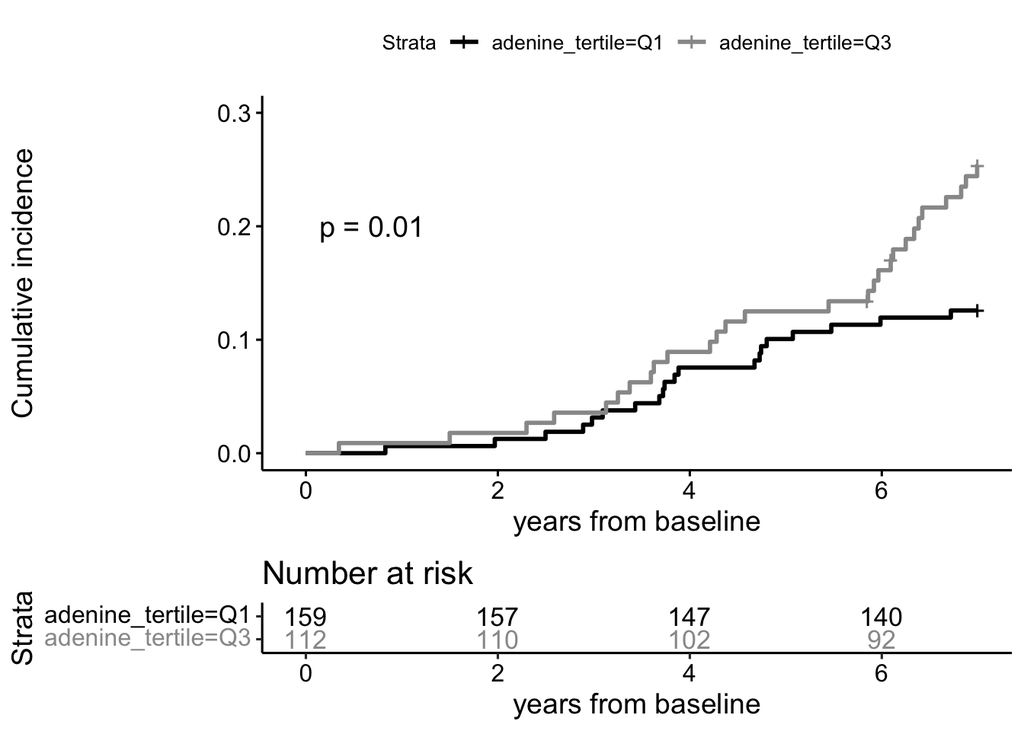

```r
#Cumulative incidence plot for normo+Micro group and p-value estimate for Q1 and Q3 for Normo+Micro group
r3_p<-CRIC%>%
  filter(adenine_tertile=='Q1' | adenine_tertile=='Q3')

ggsurvplot(survfit(Surv(r3_p$time, r3_p$event)~r3_p$adenine_tertile,data=r3_p),xlim=c(-0.1,7), ylim=c(0,0.3), conf.int = FALSE, pval = TRUE,
           palette = c("black", "grey60","blue"),
           risk.table = TRUE, risk.table.col = "strata",
           fun = "event", xlab = "years from baseline",ylab = c("Cumulative incidence"))
```

```r
#surv_diff <- survdiff(Surv(r3_p$time, r3_p$event) ~ r3_p$adenine_tertile, data=r3_p)
#surv_diff
```

## 6.1 Apply cox’s model to Full cohorts with adjusted (macro group)

```r
#Select Macro group from subset_dataset
idx<-which(subset_dataset$acr_group=="macro")
CRIC<-subset_dataset[idx,]%>%
  na.omit()

#Apply cox's model to Macro group
coxobj_Q2vsQ1<-coxph(formula=Surv(CRIC$time, CRIC$event)~
                        age+adenine_tertile+race_ethnicity_cat+bmi+sex+hemoglobin_a1c+log_acr+egfr_cric_v3y0, data = CRIC)
print(paste("Cox's model Results for Macro= "))
```

```
## [1] "Cox's model Results for Macro= "
```

```r
coxobj_Q2vsQ1
```

```
## Call:
## coxph(formula = Surv(CRIC$time, CRIC$event) ~ age + adenine_tertile +
##     race_ethnicity_cat + bmi + sex + hemoglobin_a1c + log_acr +
##     egfr_cric_v3y0, data = CRIC)
##
##                                 coef exp(coef)  se(coef)      z        p
## age                        -0.001349  0.998652  0.006864 -0.197  0.84420
## adenine_tertileQ2           0.548953  1.731439  0.197808  2.775  0.00552
## adenine_tertileQ3           0.306366  1.358480  0.214419  1.429  0.15306
## race_ethnicity_cathispanic -0.332737  0.716959  0.177488 -1.875  0.06083
## race_ethnicity_catother    -0.214699  0.806784  0.395484 -0.543  0.58721
## race_ethnicity_catwhite    -0.478573  0.619667  0.186319 -2.569  0.01021
## bmi                        -0.028332  0.972065  0.009149 -3.097  0.00196
## sex                        -0.136800  0.872144  0.163489 -0.837  0.40273
## hemoglobin_a1c              0.036737  1.037420  0.046211  0.795  0.42663
## log_acr                     0.624942  1.868138  0.080889  7.726 1.11e-14
## egfr_cric_v3y0             -0.068667  0.933638  0.007501 -9.154  < 2e-16
##
## Likelihood ratio test=181.9  on 11 df, p=< 2.2e-16
## n= 301, number of events= 228
##    (49 observations deleted due to missingness)
```

```r
exp(confint(coxobj_Q2vsQ1))
```

```
##                                2.5 %    97.5 %
## age                        0.9853069 1.0121777
## adenine_tertileQ2          1.1749863 2.5514180
## adenine_tertileQ3          0.8923581 2.0680803
## race_ethnicity_cathispanic 0.5063098 1.0152483
## race_ethnicity_catother    0.3716388 1.7514339
## race_ethnicity_catwhite    0.4300942 0.8927973
## bmi                        0.9547903 0.9896531
## sex                        0.6330334 1.2015725
## hemoglobin_a1c             0.9475878 1.1357675
## log_acr                    1.5942486 2.1890806
## egfr_cric_v3y0             0.9200119 0.9474656
```